# DataWhale 组队学习 R语言数据分析 Task 1 数据结构与数据集篇

Fin

2021-07-15

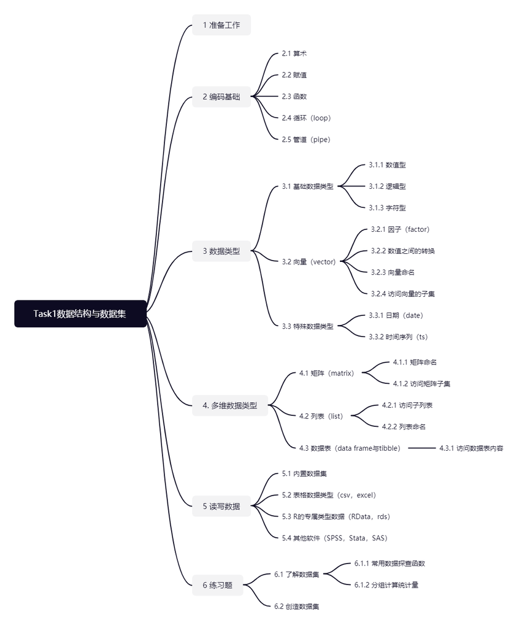

# 1 准备工作

这节组队学习的目的主要是帮助你上手R的基本编程逻辑，了解一些R编程的基本概念，包括各个数据类型和数据集的读取与保存。

在开始我们的学习之前，不要忘记在R Studio中切换到组队学习专属的项目，打开一个R script 文件或者R Markdown文件（详见入门篇）。

# 2 编码基础

首先我们来了解一些基本的编码操作。在R Studio中想要运行代码可以在控制台Console中键入代码后点击回车。这样运行的代码会被保存在当前项目的`.Rhistory`文件中，也可以在R Studio 界面右上角的 History 面板中找到，但是不会被明确地保存下来作为一个脚本文件。一般只有在我们想要运行一些简单的指令或者计算的时候才会采取这种方式。更常见的是将代码写在脚本文件中，选中相应的代码后点击界面上方的Run或者快捷键（`Ctrl` + `Enter`）来运行。

## 2.1 算术

你可以直接运行计算命令。计算符号包括加`+`、减`-`、乘`*`、除`/`、求幂`^`以及求余数`%%`等。值得一提的是开平方根有他自己单独的函数`sqrt`。

```r
1 + 1
```

```
## [1] 2
```

```r
1 - 1
```

```
## [1] 0
```

```r
1 * 2
```

```
## [1] 2
```

```r
1/2
```

```
## [1] 0.5
```

```r
3%%2
```

```
## [1] 1
```

```r
2^(1/2)
```

```
## [1] 1.414214
```

```r
sqrt(2)
```

```
## [1] 1.414214
```

## 2.2 赋值

在R里，我们可以为一个“东西”取一个名字，这个“东西”可以是一个值、一个向量、或者一个函数等，这样我们就可以之后再获取存储在这个名字下面的信息。

```r
# 将数字42赋予名叫x的变量
x <- 42
# 在R中运行一个物体的名字 R将会打印出（print）该物体的值
x
```

```
## [1] 42
```

在R中基础赋值的符号有三种：

1. 一个向左的箭头`<-`表示将箭头右方的值取名叫做箭头左侧的名字，或者将箭头右侧的值存储在箭头左侧的名字里；
2. 一个向右的箭头`->`表示将箭头左侧的值储存在箭头右侧的名字里；
3. 一个等号`=`表示将箭头右侧的值存储在箭头左侧的名字里（同1）。

总结，**凡是赋值都用`<-`**，凡是设参（之后会说到）都用`=`。

在R Studio中可以使用快捷键`Alt` + `-`来输入`<-`，这样就不用每次都点两次键啦。这样还有一个好处，就是R Studio会自动识别当前的输入语言，从而选择最佳的赋值符号。大多数情况下这也就是说他会输入R的`<-`，如果你在R Studio里用Python的话就会自动变成`=`啦。

原来作用于单纯数字上的算术运算现在即可用变量名称代替具体的数值。

```r
y <- 21
x + y
```

```
## [1] 63
```

```r
x <- x + y
```

## 2.3 函数

R是一个非纯函数式编程（Functional Programming）的语言，与你平时可能所熟悉的面向对象程序设计（Object-Oriented Programming）的编程语言（比如Python）不一样。这意味着在R中，相对于以类（Class）与对象（Object）的思路思考问题，我们要更多地定义函数（Function）以及考虑函数的输入与输出来进行运算。（如果你不知道我在这里说什么，请忽略这段话。）

在R中，所有的运算都是通过函数来达成的。我们可以用和之前一样的赋值方法（`<-`）来将一个函数存储在一个名字下。请看以下示例：

```r
addone <- function(x = 0) {
    x + 1
}
```

这里我创建了一个名为`addone`的函数，这个函数的作用就是将输入值在函数内部存储在名为`x`的参数里，在名为`x`的值上加一，再返回结果。如果没有输入值的话，`x`的默认值是`x = 0`。

```r
# 作用在数字上
addone(42)
```

```
## [1] 43
```

```r
# 作用在变量上
y <- 42
addone(y)
```

```
## [1] 43
```

如你可见，调用函数的方法就是在函数的名字后边加小括号，再在小括号中输入参数（arguments）。当函数有多个可选参数的时候，建议输入参数的时候使用等号`=`明确函数名称。这便是之前提到过的等号的设参用法。

```r
addone(x = 42)
```

```
## [1] 43
```

如果你没有使用小括号而是直接在控制台中运行函数的名字的话，像以前一样，R会直接打印出这个函数的内容，即源代码：

```r
addone
```

```
## function(x = 0) {
##     x + 1
## }
## <environment: 0x00000000152a8198>
```

当你完成了一个复杂的计算，不要忘记把结果储存在一个名字下，否则结果不会保存下来，只会在控制台中一闪而过。

```r
y <- 42
y_plusone <- addone(y)
```

## 2.4 循环（loop）

使用代码很重要的一个原因是可以重复进行多次相同或有规律的操作，也就是循环了。

R中的循环函数包括`for`，`while`，和`repeat`。在这里我们简单用一个例子来介绍一下最灵活的`for`循环：

```r
x <- 0
for (i in 1:3) {
    x <- x + i
    print(x)
}
```

```
## [1] 1
## [1] 3
## [1] 6
```

在最开始的时候，我们让`x`等于0。在接下来进行的循环操作中，紧跟在`for`之后的小括号里给出了每个回合当中会变化的参数，叫做`i`。`i`后边的`in`之后给出的是参数`i`在回合中的可能取值，也就是从1到3的正整数。最后大括号中给出每个回合的操作，在`x`上加上`i`的值，重新取名为`x`，再打印出来。

整个流程下来：

第一个回合`x`一开始是0，在第一个回合中`i`是1，经过计算赋值`x`变成了1，打印后进入第二个回合；  
第二个回合`x`一开始是1，在第二个回合中`i`是2，经过计算赋值`x`变成了3，打印后进入第二个回合；  
第三个回合`x`一开始是3，在第三个回合中`i`是3，经过计算赋值`x`变成了6，打印后结束循环。

## 2.5 管道（pipe）

如果我们想要对一个对象进行多个函数的操作，比如说想要使用我们刚刚定义的`addone`函数，还有新定义的`addtwo`，`addthree`，我们可以按照普通调用函数的方法一个套一个：

```r
addone <- function(x) x + 1
addtwo <- function(x) x + 2
addthree <- function(x) x + 3

x <- 0
addthree(addtwo(addone(x)))
```

```
## [1] 6
```

在这种常规的方法下，函数运行的顺序，和我们读函数的顺序，都是从内到外的。比如在上边的操作中，我们先用了`addone`给0加1，又用了`addtwo`，最后用了`addthree`。这样的坏处也是显而易见的，即可读性很差。想象一下你要对一个数据列表连续使用十几个函数，每个函数里都有其自己不同的参数，这么一系列操作如果用这个常规方法的话必然会使代码变成一个很难读的庞然大物。

`magrittr`包提供了另一种使用函数的办法，即使用`%>%`这个符号函数进行方法链（method chain）的操作。你可以把这个符号叫做管道。如果我们用管道来重写之前的一连串操作，代码会变成：

```r
# tidyverse也包含了管道符号
library(tidyverse)

x %>%
    addone() %>%
    addtwo() %>%
    addthree()
```

```
## [1] 6
```

这个符号的具体含义简单来说是“将上一步运行的结果放在下一步运行的函数的第一个参数的位置上”。在这个例子中，`x`被当作`addone`的第一个参数被加一。`addone`的运行结果被当成下一步`addtwo`的第一个参数被加二，其运行结果最后被当成`addthree`的第一个参数被加三，最终得到结果。

经过了管道的改写之后，函数的可读性得到了大幅上升。从常规的“从内到外”读法，变成了“从上到下，从左到右”。虽然需要运行额外R包，但是由于符合阅读习惯和数据清洗流程的特点，管道在数据分析的领域被普遍使用。

关于管道符号的具体使用规则详见`` ?`%>%` ``。

# 3 数据类型

## 3.1 基础数据类型

在R中有五种基础数据类型，包括三个数值型、一个逻辑型和一个字符型。

### 3.1.1 数值型

数值型数据包括三种，分别是默认的实数数值型数据（double）、整数类型（integer）和复数类型（complex）：

```r
# numeric
a <- 132.2345
# Inf integer
b <- 132L
# complex
c <- 2 + (0+3i)
```

实数数值型数据每个值占用8个字节（bytes），是最常见的数值型数据。如果没有做特别处理，我们平时见到的数字都是这个类型的——单纯的数字罢了。

整数类型，正如它的名字一样，只包含整数而没有小数部分。我们可以在整数末尾加上一个大写的L来表示这个数字是一个整数类型的数据。如果没有加大写的L的话，虽然只输入了一个整数，但是这个整数是实数数值类型的整数，而不是整数类型。他们的区别在于实数数值类型的整数和和非整数一样都占用8个字节，而整数类型只占用4个字节。平时用起来区别不大，但是如果数据量比较大且都是整数的话推荐使用整数类型来节约空间。

复数类型便是包含复数部分的数值类型了。只要在实数部分后边加上虚数部分并且用小写字母i来代表虚数单位，这个数值便是复数类型。鉴于数据分析领域基本不会涉及复数，我们在这次组队学习不去讨论复数类型。

判断一个数值是什么类型，可以用`typeof()`:

```r
typeof(a)
```

```
## [1] "double"
```

```r
typeof(b)
```

```
## [1] "integer"
```

```r
typeof(c)
```

```
## [1] "complex"
```

### 3.1.2 逻辑型

逻辑型（logical）数据只包括两个值，`TRUE`（`T`） 和 `FALSE`（`F`）:

```r
TRUE
```

```
## [1] TRUE
```

```r
T
```

```
## [1] TRUE
```

```r
FALSE
```

```
## [1] FALSE
```

```r
F
```

```
## [1] FALSE
```

尽管一个字母的缩写和全拼效果是一样的，但是一个好的编程习惯是始终使用大写全拼的`TRUE`和`FALSE`。这样可以增加可读性，也会减小因为命名产生的使用错误。比如，有些时候涉及到时间序列时，一些用户喜欢将最大时序上限命名为`T`，这个时候就不能用`T`来代表`TRUE`了。

说到逻辑型数据，就不得不说到逻辑算符。这里我们只考虑三个，分别是“和”（and）`&`、“或”（or）`|`、“否”（not）`!`。

```r
TRUE & FALSE
```

```
## [1] FALSE
```

```r
TRUE | FALSE
```

```
## [1] TRUE
```

```r
!TRUE
```

```
## [1] FALSE
```

### 3.1.3 字符型

字符型数据（character）可以总结为“任何带引号的值”。它可以是一个字母、一个单词、一句话、或者任何用引号框起来的数值或逻辑。

```r
string_a <- "A"
string_b <- "letter"
string_c <- "This is a sentence."
string_d <- "42"
string_e <- "TRUE"
```

在输入的时候，即使是数字或者逻辑型的`TRUE`和`FALSE`，只要加上了引号，他们就变成了字符型的数据，而不再带有数值型或逻辑型的特性。要注意区分。

```r
typeof(42)
```

```
## [1] "double"
```

```r
typeof("42")
```

```
## [1] "character"
```

```r
typeof(TRUE)
```

```
## [1] "logical"
```

```r
typeof("TRUE")
```

```
## [1] "character"
```

字符型是最“自由”的数据类型，因为它的内容可以是任何字符，任何其他的数据类型也可以转化为字符型数据。比如你可以把一个数值型数据加上引号来当作字符型数据来解读。但是反过来却不可以：你没有办法把一个字符当作数字来解读。数据之间的转化我们会在第3.2.2节讲到。

在R中，单引号（`'`）和双引号（`"`）是等效的，但是我们推荐大多数情况下使用双引号，只有在引号内有双引号的时候使用单引号去引双引号（比如`' This is an "example". '`）。这主要是为了帮助其他语言（C, C++, Java等）的用户区分单双引号的细微区别。在C语言里，单双引号不是等效的。R语言中的（单）双引号大致是与C语言中的双引号等效的。

## 3.2 向量（vector）

这里说到的向量主要指基础向量类型（atomic vector）。 向量是由一组相同类型的值组成的一维序列。根据值的类型不同，我们会有不同类型的向量。 相对应之前的数值、逻辑和字符型的基础数据类型，这里我们也有数值、逻辑和字符型的向量类型。

```r
vec_num <- c(1, 2, 3)
vec_log <- c(TRUE, FALSE, TRUE)
vec_cha <- c("A", "B", "middle school")
```

使用函数`c()`来构建向量。可以进行向量上的运算，而不用一个一个值地单独去计算。

```r
vec_A <- c(1, 2, 3)
vec_B <- c(3, 5, 6)
vec_A + vec_B  # 等同于 c(1 + 3, 2 + 5, 3 + 6)
```

```
## [1] 4 7 9
```

```r
!vec_log
```

```
## [1] FALSE  TRUE FALSE
```

也有相应的作用于向量上的函数，可以计算相应的统计量。比如求和的`sum`、求方差的`var`、平均值的`mean`等：

```r
sum(vec_A)
```

```
## [1] 6
```

```r
var(vec_A)
```

```
## [1] 1
```

```r
mean(vec_A)
```

```
## [1] 2
```

### 3.2.1 因子（factor）

除了之前提到的基础数据类型组成的向量外，还有一类重要的的向量类型便是因子，可以使用函数`factor`和`c`组合来创建。

```r
vec_fac <- factor(c("male", "female", "male", "female", "female"))
vec_fac
```

```
## [1] male   female male   female female
## Levels: female male
```

从表面上看，一个因子向量和字符向量很相似，都是一系列带引号的字符组成的。它与字符向量的主要区别在于因子向量的独特值（levels）是有限个数的。因子向量的所有元素都是由这些有限个数的独特值组成的。比如在以上的例子中，虽然`vec_fac`由五个元素组成，但是只包括了两个独特值“male”和“female”。

```r
# 查看因子向量的独特值
levels(vec_fac)
```

```
## [1] "female" "male"
```

你也可以用函数`ordered`或者`factor`里的`ordered = TRUE`参数（argument）创造一个有内在顺序的因子向量，内在顺序可以用`levels`参数来手动设定：

```r
educ <- ordered(c("kindergarten", "primary school", "middle school", "primary school",
    "middle school", "kindergarten"), levels = c("kindergarten", "primary school",
    "middle school"))
# 等同于
educ <- factor(c("kindergarten", "primary school", "middle school", "primary school",
    "middle school", "kindergarten"), ordered = TRUE, levels = c("kindergarten",
    "primary school", "middle school"))

educ
```

```
## [1] kindergarten   primary school middle school  primary school middle school
## [6] kindergarten
## Levels: kindergarten < primary school < middle school
```

实质上，R把因子向量当作整数型数值向量来对待。这也就意味着用因子向量替代字符向量可以剩下很多字节。